# slide_deck_template slides

### Exploring Relationship between BorrowerRate, ProsperRatings and Home-Owning Customers

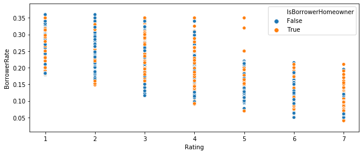

```python
# plotting a boxplot to explore all 3 variables

#sb.boxplot(data = loans_clean2, x = 'Rating', y = 'BorrowerRate', hue = 'IsBorrowerHomeowner');

# customizing width and height of plot

dim = sb.scatterplot(data = loans_clean, x = 'Rating', y = 'BorrowerRate', hue = 'IsBorrowerHomeowner');
dim.figure.set_figwidth(10)
dim.figure.set_figheight(4)
```

### Exploring Yearly Trend in Prosper BorrowerRate for Home Owners versus Non-Home Owners

The plot above, we can see that the median premium(BorrowerRate) for home-owning customers is always lesser than the counterpart for each year that passes. It seems that the increase in premiums is a way for lenders to hedge the risks involved in lending to non-home owners.

We can also infer from the plot that the greatest difference in premiums was evident between 2008 and 2010. This suggests that the bigger gap in premiums betwen Home owners and Non-Home owners may have been a coping mecahnism for Prosper to endure the 2008 financial crises and the few years that came after 2008

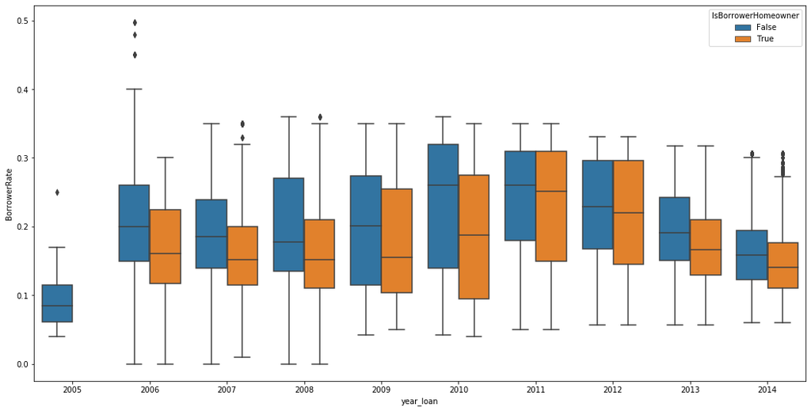

```python
# plotting a boxplot to explore all 3 variables

#sb.boxplot(data = loans_clean, x = 'year_loan', y = 'BorrowerRate', hue = 'IsBorrowerHomeowner');

# customizing width and height of plot

dim = sb.boxplot(data = loans_clean, x = 'year_loan', y = 'BorrowerRate', hue = 'IsBorrowerHomeowner');
dim.figure.set_figwidth(18)
dim.figure.set_figheight(9)
```

# Thank You For Your Time

### Feel free to leave a comment